[figure not shown]

# What is Recursion?

- The process in which a function calls itself directly or indirectly is called recursion and the corresponding function is called a recursive function.
- Using a recursive algorithm, certain problems can be solved quite easily.
- All recursive functions can be solved Iteratively

# Need of Recursion?

- Recursion is an amazing technique with the help of which we can reduce the length of our code and make it easier to read and write.
- Using a recursive algorithm, certain problems can be solved quite easily. Examples of such problems are Towers of Hanoi (TOH), Inorder/Preorder/Postorder Tree Traversals, DFS of Graph, etc.
- Toughest to Understand but Important. Foundation of backtracking, DP.

# Recursive vs Iterative

- Iterative - Factorial

  ```
  def get_factorial_for_loop(n):
    result = 1
    if n > 1:
        for i in range(1, n+1):
            result = result * i
        return result
    else:
        return 'n has to be positive'
  ```

- Recursive -Factorial

  ```
  def get_factorial_recursively(n):
    if n <= 1:
        return 1
    else:
        return n * get_factorial_recursively(n-1)
  ```

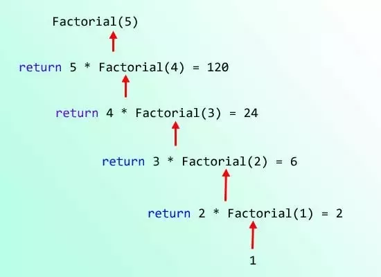

# Memory Layout of a Process (Python Programs)

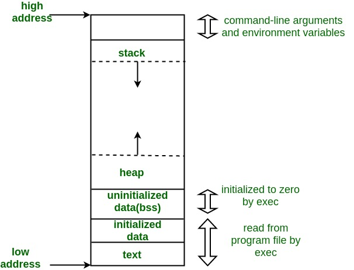

Each time a recursive function calls itself, a new stack frame is used, so one set of variables doesn’t interfere with the variables from another instance of the function.

Read More: [Link](https://www.geeksforgeeks.org/memory-layout-of-c-program/)

# Memory Allocation in Recursion

- When a function is called, its memory is allocated on a stack.
- Stacks in computing architectures are the regions of memory where data is added or removed in a last-in-first-out (LIFO) process.
- When a function executes, it adds its state data to the top of the stack. When the function exits, this data is removed from the stack.
- Simulation Example: [Link](https://www.educative.io/courses/recursion-for-coding-interviews-in-python/B8wMXy0nmvk#Memory-Allocation-in-Recursion)

# Types of Recursive Programs

There are mainly 2 types of recursive functions:

1) Direct Recursion - In this type of recursion, the function calls itself.

- Tail Recursion - A recursive call is said to be tail-recursive if it is the last statement to be executed inside the function.

```
def fact(n):
    if n == 0:
        return 1  # Base case
    return (n * fact(n - 1))  # Not a tail-recursive call


print(fact(5))
---------------------------------
def GCD(a, b):
    if b == 0:
        return a  # Base case
    return GCD(b, a % b)  # Tail Recursive Call


print(GCD(49, 35))
```

- Head Recursion - If in a recursive function, the last statement is not a recursive call, i.e., during the unwinding phase, there are still some steps to occur, and then it is called head recursion.

```
def headr(n):
    if n > 0:
        headr(n - 1)
        print(n, end=" ")


p = 5
headr(5)
```

2) Indirect Recursion - In this type of recursion, the function calls another function which calls the original function.

```
def A(n):
    if n > 0:
        print("", n, end='')
        B(n + 1)


def B(n):
    if n > 1:
        print("", n, end='')
        A(n - 5)


A(20)
```

# Components of Recursion

Recursive function in Python has two parts:

(a) Base Case - This helps us to terminate the recursive function. It is a simple case that can be answered directly and doesn't use recursion. If satisfied, it returns the final computable answer. If this is omitted, the function will run till infinity.

Python interpreter limits the number of recursive calls for a function to 1000 by giving a recursion error.

(b) General (Recursive) Case - This case uses recursion and is called unless the base condition is satisfied. Also called Recurrence relation

```
def rec_func_name():
   if(condition)                       # base case
       simple statement without recursion
   else                                # general case
       statement calling rec_func_name()
```

# Practice Problems: Examples

1. Palindrome check
2. Hanoi tower problem
3. All Permutation Problem
4. Grid - Unique Paths
5. N Queen Problem
6. Sort With Quicksort
7. Flatten Nested Data e.g. JSON

# Example 01: Palindrome check

- Problem Statement: Given a string, write a python function to check if it is palindrome or not. A string is said to be palindrome if the reverse of the string is the same as string. For example, “radar” is a palindrome, but “radix” is not a palindrome.
- Iterative Approach

```python
# function to check string is
# palindrome or not
def isPalindrome(str):

    # Run loop from 0 to len/2
    for i in range(0, int(len(str)/2)):
        if str[i] != str[len(str)-i-1]:
            return False
    return True

# main function
s = "malayalam"
ans = isPalindrome(s)

if (ans):
    print("Yes")
else:
    print("No")
```

```
Yes
```

- Base Case & Recurrence Relation

```python
#Base Case
If n<=1 return true;

#Recurrence Relation

F(n) = F(n-2) if S[0]== S[n-1]
     = False  if S[0] != S[n-1]
```

- Recursive Code

```python
# Recursive function to check if a
# string is palindrome

def isPalindrome(s):

    # to change it the string is similar case
    s = s.lower()
    # length of s
    l = len(s)

    # if length is less than 2
    if l < 2:
        return True

    # If s[0] and s[l-1] are equal
    elif s[0] == s[l - 1]:

        # Call is palindrome form substring(1,l-1)
        return isPalindrome(s[1: l - 1])

    else:
        return False

# Driver Code
s = "MalaYaLam"
ans = isPalindrome(s)

if ans:
    print("Yes")

else:
    print("No")
```

```
Yes
```

```python
#To Run
```

# Example 02: Tower of Hanoi Problem

- Problem Statement: The problem is to move all discs from the left to the right with three conditions: one disc at a time, move only a disc on top, and not putting larger disc on top of a smaller one.

[figure not shown]

Here is a soution example for 3 discs:

[figure not shown]

- Iterative Approach

```python
# Python3 program for iterative Tower of Hanoi
import sys

# A structure to represent a stack
class Stack:
    # Constructor to set the data of
    # the newly created tree node
    def __init__(self, capacity):
        self.capacity = capacity
        self.top = -1
        self.array = [0]*capacity

# function to create a stack of given capacity.
def createStack(capacity):
    stack = Stack(capacity)
    return stack

# Stack is full when top is equal to the last index
def isFull(stack):
    return (stack.top == (stack.capacity - 1))

# Stack is empty when top is equal to -1
def isEmpty(stack):
    return (stack.top == -1)

# Function to add an item to stack.
# It increases top by 1
def push(stack, item):
    if(isFull(stack)):
        return
    stack.top+=1
    stack.array[stack.top] = item

# Function to remove an item from stack.
# It decreases top by 1
def Pop(stack):
    if(isEmpty(stack)):
        return -sys.maxsize
    Top = stack.top
    stack.top-=1
    return stack.array[Top]



# Function to implement legal
# movement between two poles
def moveDisksBetweenTwoPoles(src, dest, s, d):
    pole1TopDisk = Pop(src)
    pole2TopDisk = Pop(dest)

    # When pole 1 is empty
    if (pole1TopDisk == -sys.maxsize):
        push(src, pole2TopDisk)
        moveDisk(d, s, pole2TopDisk)

    # When pole2 pole is empty
    elif (pole2TopDisk == -sys.maxsize):
        push(dest, pole1TopDisk)
        moveDisk(s, d, pole1TopDisk)

    # When top disk of pole1 > top disk of pole2
    elif (pole1TopDisk > pole2TopDisk):
        push(src, pole1TopDisk)
        push(src, pole2TopDisk)
        moveDisk(d, s, pole2TopDisk)

    # When top disk of pole1 < top disk of pole2
    else:
        push(dest, pole2TopDisk)
        push(dest, pole1TopDisk)
        moveDisk(s, d, pole1TopDisk)

# Function to show the movement of disks
def moveDisk(fromPeg, toPeg, disk):
    print("Move the disk", disk, "from '", fromPeg, "' to '", toPeg, "'")

# Function to implement TOH puzzle
def tohIterative(num_of_disks, src, aux, dest):
    s, d, a = 'S', 'D', 'A'

    # If number of disks is even, then interchange
    # destination pole and auxiliary pole
    if (num_of_disks % 2 == 0):
        temp = d
        d = a
        a = temp
    total_num_of_moves = int(pow(2, num_of_disks) - 1)

    # Larger disks will be pushed first
    for i in range(num_of_disks, 0, -1):
        push(src, i)

    for i in range(1, total_num_of_moves + 1):
        if (i % 3 == 1):
            moveDisksBetweenTwoPoles(src, dest, s, d)

        elif (i % 3 == 2):
            moveDisksBetweenTwoPoles(src, aux, s, a)

        elif (i % 3 == 0):
            moveDisksBetweenTwoPoles(aux, dest, a, d)

# Input: number of disks
num_of_disks = 3

# Create three stacks of size 'num_of_disks'
# to hold the disks
src = createStack(num_of_disks)
dest = createStack(num_of_disks)
aux = createStack(num_of_disks)

tohIterative(num_of_disks, src, aux, dest)

# This code is contributed by divyeshrabadiya07.
```

```
Move the disk 1 from ' S ' to ' D '
Move the disk 2 from ' S ' to ' A '
Move the disk 1 from ' D ' to ' A '
Move the disk 3 from ' S ' to ' D '
Move the disk 1 from ' A ' to ' S '
Move the disk 2 from ' A ' to ' D '
Move the disk 1 from ' S ' to ' D '
```

- Base Case & Recurrence Relation

```python
# Base Case
If n==1 print("Move the Disc from Source to Target");

# Recurrence Relation

F(n,src,tgt,aux) = F(n-1,src,aux,tgt)  #magic function
                   print("Move the Disc from Source to Target");
                   F(n-1,aux,tgt,src)  #magic function
```

- Recursive Code

```python
# Recursive Python function to solve the tower of hanoi

def TowerOfHanoi(n , source, destination, auxiliary):
    if n==1:
        print ("Move disk 1 from source",source,"to destination",destination)
        return
    TowerOfHanoi(n-1, source, auxiliary, destination)
    print ("Move disk",n,"from source",source,"to destination",destination)
    TowerOfHanoi(n-1, auxiliary, destination, source)

# Driver code
n = 4
TowerOfHanoi(n,'A','B','C')
# A, C, B are the name of rods
```

```
Move disk 1 from source A to destination C
Move disk 2 from source A to destination B
Move disk 1 from source C to destination B
Move disk 3 from source A to destination C
Move disk 1 from source B to destination A
Move disk 2 from source B to destination C
Move disk 1 from source A to destination C
Move disk 4 from source A to destination B
Move disk 1 from source C to destination B
Move disk 2 from source C to destination A
Move disk 1 from source B to destination A
Move disk 3 from source C to destination B
Move disk 1 from source A to destination C
Move disk 2 from source A to destination B
Move disk 1 from source C to destination B
```

```python
# To Run
```

# Example 03: All Permutations

- Problem Statement: Print all permutations of a given set

Input: A,B,C

Output: [A,B,C] [A,C,B] [B,A,C] [B,C,A] [C,A,B] [C,B,A]

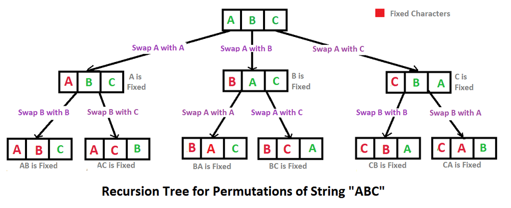

- Iterative Approach

```python
# Iterative function to generate all permutations of a string in Python
def permutations(s):

    # base case
    if not s:
        return []

    # create a list to store (partial) permutations
    partial = []

    # initialize the list with the first character of the string
    partial.append(s[0])

    # do for every character of the specified string
    for i in range(1, len(s)):

        # consider previously constructed partial permutation one by one

        # iterate backward
        for j in reversed(range(len(partial))):

            # remove the current partial permutation from the list
            curr = partial.pop(j)

            # Insert the next character of the specified string into all
            # possible positions of current partial permutation.
            # Then insert each of these newly constructed strings into the list

            for k in range(len(curr) + 1):
                partial.append(curr[:k] + s[i] + curr[k:])

    print(partial, end='')


if __name__ == '__main__':

    s = 'ABC'
    permutations(s)
```

```
['CAB', 'ACB', 'ABC', 'CBA', 'BCA', 'BAC']
```

- Base Case & Recurrence Relation

```python
#Base Case
If n<=1 print(string);

#Recurrence Relation

F(n) = swap l to each of the char one at a time
       F(n-1)
       swap back
```

- Recursive Code

```python
def permute(a, l, r):
    if l==r:
        print (''.join(a))
    else:
        for i in range(l,r):
            a[l], a[i] = a[i], a[l]
            permute(a, l+1, r)      # recursion
            a[l], a[i] = a[i], a[l] # backtrack

# Driver program to test the above function
string = "ABC"
n = len(string)
a = list(string)
permute(a, 0, n)
```

```
ABC
ACB
BAC
BCA
CBA
CAB
```

```python
# To Run
```

# Example 04: Grid- Unique Paths

- Problem Statement: There is a robot on an m x n grid. The robot is initially located at the top-left corner (i.e., grid[0][0]). The robot tries to move to the bottom-right corner (i.e., grid[m - 1][n - 1]). The robot can only move either down or right at any point in time.

  Given the two integers m and n, return the number of possible unique paths that the robot can take to reach the bottom-right corner.

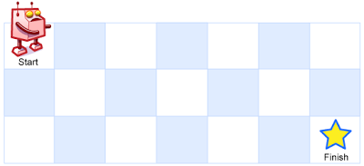

- Iterative Approach

```python
# O(m*n) space
def uniquePaths2( m, n):
    if not m or not n:
        return 0
    dp = [[1 for _ in range(n)] for _ in range(m)]
    for i in range(1, m):
        for j in range(1, n):
            dp[i][j] = dp[i-1][j] + dp[i][j-1]
    return dp[-1][-1]

uniquePaths2(3,3)
```

```
6
```

- Base Case & Recurrence Relation

```python
# Base Case
If i==m-1 && j==n-1 return 1;
If i>m-1 || j>n-1 return 0;

# Recurrence Relation

F(i,j) = F(i+1,j) + F(i, j+1)
```

- Recursive Code

```python
def uniquePaths(m, n, i=0, j=0):
    if i >= m or j >= n:      return 0
    if i == m-1 and j == n-1: return 1

    return uniquePaths(m, n, i+1, j) + uniquePaths(m, n, i, j+1)


uniquePaths(3,3)
```

```
6
```

```python
# To Run
```

# Example 05: N Queen Problem

- Problem Statement: The N Queen is the problem of placing N chess queens on an N×N chessboard so that no two queens attack each other.

  Generate a possible ordering of queens in n*n chessboard

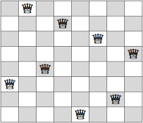

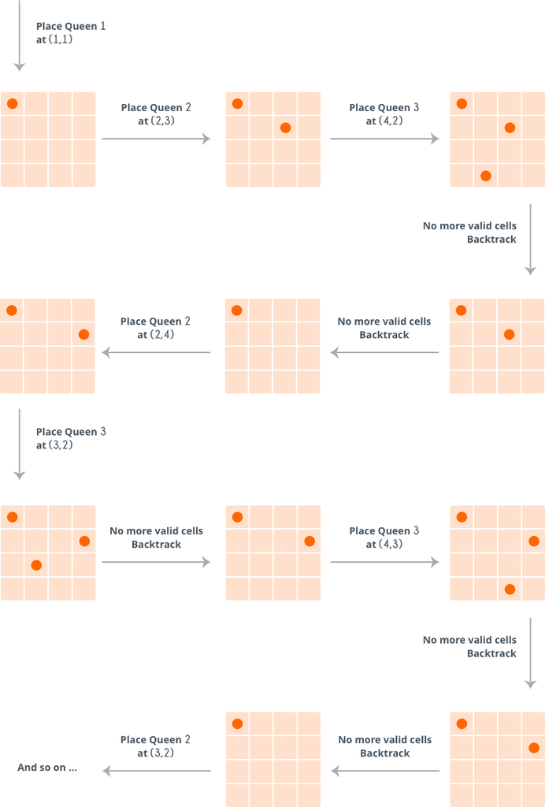

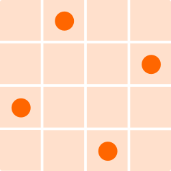

```python
# Python program to solve N Queen
# Problem using backtracking

global N
N = 4

def printSolution(board):
    for i in range(N):
        for j in range(N):
            print (board[i][j],end=' ')
        print()


# A utility function to check if a queen can
# be placed on board[row][col]. Note that this
# function is called when "col" queens are
# already placed in columns from 0 to col -1.
# So we need to check only left side for
# attacking queens
def isSafe(board, row, col):

    # Check this row on left side
    for i in range(col):
        if board[row][i] == 1:
            return False

    # Check upper diagonal on left side
    for i, j in zip(range(row, -1, -1), range(col, -1, -1)):
        if board[i][j] == 1:
            return False

    # Check lower diagonal on left side
    for i, j in zip(range(row, N, 1), range(col, -1, -1)):
        if board[i][j] == 1:
            return False

    return True

def solveNQUtil(board, col):
    # base case: If all queens are placed
    # then return true
    if col >= N:
        return True

    # Consider this column and try placing
    # this queen in all rows one by one
    for i in range(N):

        if isSafe(board, i, col):
            # Place this queen in board[i][col]
            board[i][col] = 1

            # recur to place rest of the queens
            if solveNQUtil(board, col + 1) == True:
                return True

            # If placing queen in board[i][col
            # doesn't lead to a solution, then
            # queen from board[i][col]
            board[i][col] = 0

    # if the queen can not be placed in any row in
    # this column col  then return false
    return False

# This function solves the N Queen problem using
# Backtracking. It mainly uses solveNQUtil() to
# solve the problem. It returns false if queens
# cannot be placed, otherwise return true and
# placement of queens in the form of 1s.
# note that there may be more than one
# solutions, this function prints one  of the
# feasible solutions.
def solveNQ():
    board = [ [0, 0, 0, 0],
              [0, 0, 0, 0],
              [0, 0, 0, 0],
              [0, 0, 0, 0]
             ]

    if solveNQUtil(board, 0) == False:
        print ("Solution does not exist")
        return False

    printSolution(board)
    return True

solveNQ()
```

```
0 0 1 0
1 0 0 0
0 0 0 1
0 1 0 0
```

```
True
```

```python
# To Run
```

# Example 06: Sort With Quicksort

The Quicksort algorithm is an efficient sorting algorithm developed by British computer scientist Tony Hoare in 1959.

The steps of the algorithm are as follows:

1. Choose the pivot item.
2. Partition the list into two sublists: Those items that are less than the pivot item & Those items that are greater than the pivot item
3. Quicksort the sublists recursively.

Animation Link: [here](https://www.hackerearth.com/practice/algorithms/sorting/quick-sort/visualize/)

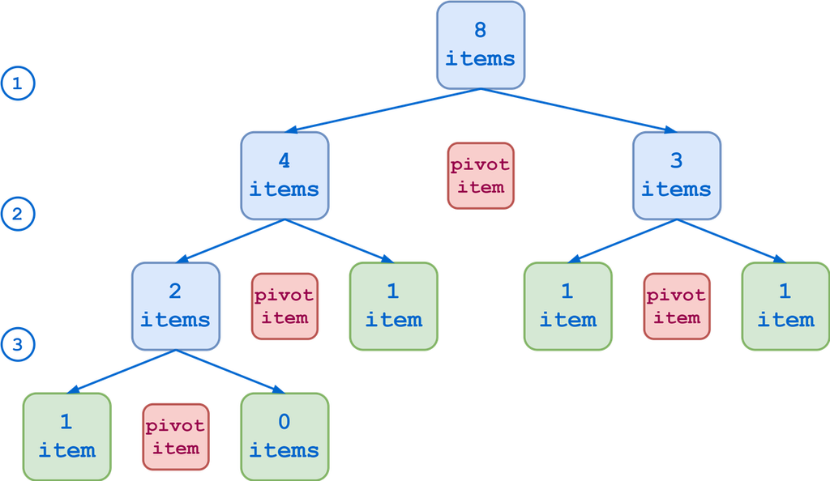

```python
#To Run
# Function to find the partition position
def partition(array, low, high):

    # choose the rightmost element as pivot
    pivot = array[high]

    # pointer for greater element
    i = low - 1

    # traverse through all elements
    # compare each element with pivot
    for j in range(low, high):
        if array[j] <= pivot:

            # If element smaller than pivot is found
            # swap it with the greater element pointed by i
            i = i + 1

            # Swapping element at i with element at j
            (array[i], array[j]) = (array[j], array[i])

    # Swap the pivot element with the greater element specified by i
    (array[i + 1], array[high]) = (array[high], array[i + 1])

    # Return the position from where partition is done
    return i + 1

# function to perform quicksort


def quickSort(array, low, high):
    if low < high:

        # Find pivot element such that
        # element smaller than pivot are on the left
        # element greater than pivot are on the right
        pi = partition(array, low, high)

        # Recursive call on the left of pivot
        quickSort(array, low, pi - 1)

        # Recursive call on the right of pivot
        quickSort(array, pi + 1, high)


data = [1, 7, 4, 1, 10, 9, -2]
print("Unsorted Array")
print(data)

size = len(data)

quickSort(data, 0, size - 1)

print('Sorted Array in Ascending Order:')
print(data)
```

```
Unsorted Array
[1, 7, 4, 1, 10, 9, -2]
Sorted Array in Ascending Order:
[-2, 1, 1, 4, 7, 9, 10]
```

# Example 07: Flatten Nested Data e.g. JSON

Somtimes we need to convert a heirarichal structure e.g. JSON to a table and vice versa. Here is how we can solve this problem

#### Simple nested data sample

```python
# Create Sample data

#example of simple nested data
jsonData1 = """
 {
    "USA": {
             "NJ"      : {
                          "Newark"     : [
                                          "Jeremy",
                                          "Stacey"
                                         ]
                         },
             "New York": {
                          "Brooklyn"   : "David",
                          "Mannhatten" : "Dan"
                         }
           },
    "CAN": {
             "MO"      : "Sarah",
             "Toronto" : {
                          "Yorkville"  : "Jessi",
                          "Lib Vill"   : "Sam"
                         }
           },
    "MEX": {
             "Tulum"      : "Elsi",
             "Berlin"     : {
                             "AAA"  : "11",
                             "BBB"  : "22",
                             "CCC"  : [
                                          "33",
                                          "44"
                                         ]
                            }
           }

  }
"""

# Expected output:

"""
    USA > NJ > Newark > Jeremy
    USA > NJ > Newark > Stacey
    USA > New York > Brooklyn > David
    USA > New York > Mannhatten > Dan
    CAN > MO > Sarah
    CAN > Toronto > Yorkville > Jessi
    CAN > Toronto > Lib Vill > Sam
    MEX > Tulum > Elsi
    MEX > Berlin > AAA > 11
    MEX > Berlin > BBB > 22
    MEX > Berlin > CCC > 33
    MEX > Berlin > CCC > 44
 """
# example of complicated nested data
```

```
'\n    USA > NJ > Newark > Jeremy\n    USA > NJ > Newark > Stacey\n    USA > New York > Brooklyn > David\n    USA > New York > Mannhatten > Dan\n    CAN > MO > Sarah\n    CAN > Toronto > Yorkville > Jessi\n    CAN > Toronto > Lib Vill > Sam\n    MEX > Tulum > Elsi\n    MEX > Berlin > AAA > 11\n    M…
```